# Biostat M280 Homework 4

Due Mar 16 @ 11:59PM

Our Apache Yarn cluster hosts the [flights](http://stat-computing.org/dataexpo/2009/the-data.html) data representing 123 million flights over 22 years. Read the [lecture notes](http://hua-zhou.github.io/teaching/biostatm280-2018winter/slides/12-sparklyr/sparklyr-flights.html) on how to access the Yarn cluster. Connect to the database using `sparklyr` and answer following questions. You can base your answers on a specific year or the whole data set.

```r
#spark_disconnect_all()
library(tidyverse)
library(sparklyr)
```

```r
library(ggplot2)

library(ggmap)
library(maps)
library(mapdata)

library(lubridate)
library(ggrepel)
library(modelr)
library(olsrr)
Sys.setenv(SPARK_HOME="/usr/lib/spark")
config <- spark_config()
sc <- spark_connect(master = "yarn-client", config = config)
#sc
```

```r
flights_tbl <- tbl(sc, 'flights')
head(flights_tbl)
```

```
## # Source:   lazy query [?? x 29]
## # Database: spark_connection
##    year month dayofmonth dayofweek deptime crsdeptime arrtime crsarrtime
##   <int> <int>      <int>     <int>   <int>      <int>   <int>      <int>
## 1    NA    NA         NA        NA      NA         NA      NA         NA
## 2  1987    10         14         3     741        730     912        849
## 3  1987    10         15         4     729        730     903        849
## 4  1987    10         17         6     741        730     918        849
## 5  1987    10         18         7     729        730     847        849
## 6  1987    10         19         1     749        730     922        849
## # ... with 21 more variables: uniquecarrier <chr>, flightnum <int>,
## #   tailnum <chr>, actualelapsedtime <int>, crselapsedtime <int>,
## #   airtime <chr>, arrdelay <int>, depdelay <int>, origin <chr>,
## #   dest <chr>, distance <int>, taxiin <chr>, taxiout <chr>,
## #   cancelled <int>, cancellationcode <chr>, diverted <int>,
## #   carrierdelay <chr>, weatherdelay <chr>, nasdelay <chr>,
## #   securitydelay <chr>, lateaircraftdelay <chr>
```

```r
airlines_tbl <- tbl(sc, 'airlines')
head(airlines_tbl)
```

```
## # Source:   lazy query [?? x 2]
## # Database: spark_connection
##   code  description
##   <chr> <chr>
## 1 Code  Description
## 2 02Q   Titan Airways
## 3 04Q   Tradewind Aviation
## 4 05Q   Comlux Aviation, AG
## 5 06Q   Master Top Linhas Aereas Ltd.
## 6 07Q   Flair Airlines Ltd.
```

```r
airports_tbl <- tbl(sc, 'airports')
head(airports_tbl)
```

```
## # Source:   lazy query [?? x 12]
## # Database: spark_connection
##   id    name   city  country faa   icao  lat   lon   alt   tz_offset dst
##   <chr> <chr>  <chr> <chr>   <chr> <chr> <chr> <chr> <chr> <chr>     <chr>
## 1 1     Gorok… Goro… Papua … GKA   AYGA  -6.0… 145.… 5282  10        U
## 2 2     Madan… Mada… Papua … MAG   AYMD  -5.2… 145.… 20    10        U
## 3 3     Mount… Moun… Papua … HGU   AYMH  -5.8… 144.… 5388  10        U
## 4 4     Nadza… Nadz… Papua … LAE   AYNZ  -6.5… 146.… 239   10        U
## 5 5     Port … Port… Papua … POM   AYPY  -9.4… 147.… 146   10        U
## 6 6     Wewak… Wewak Papua … WWK   AYWK  -3.5… 143.… 19    10        U
## # ... with 1 more variable: tz_name <chr>
```

**1. Map the top 10 busiest airports. Size of dots should reflect the number of flights through that destination. Hint: You may find this tutorial on [Making Maps in R](http://eriqande.github.io/rep-res-web/lectures/making-maps-with-R.html) helpful.**

```r
#10 busiest airports in year 2002

#origin airpots
f_origin <- flights_tbl %>%
  filter(year == 2002 & !is.na(origin)) %>%
  group_by(origin) %>%
  tally() %>%
  arrange(desc(n)) %>%
  collect() %>%
  head(10)

colnames(f_origin) <- c("origin", "outgoing")

#destination airports
  f_dest <- flights_tbl %>%
    filter(year == 2002 & !is.na(dest)) %>%
    group_by(dest) %>%
    tally() %>%
    arrange(desc(n)) %>%
    collect() %>%
    head(10)

colnames(f_dest) <- c("dest", "incoming")

#combined table (top origin and dest airports)
combined <- f_origin %>%
  left_join(f_dest, by = c("origin" = "dest")) %>%
  transmute(airport = origin,
            n = outgoing + incoming) %>%
  head(10)



#airport longitude and latitude
  location <- combined %>%
    left_join(airports_tbl, by = c("airport" = "faa"), copy = TRUE) %>%
    select(airport, n, lon, lat) %>%
    mutate(
      lon = as.double(lon),
      lat = as.double(lat)) %>%
    collect()

  location
```

```
## # A tibble: 10 x 4
##    airport       n    lon   lat
##    <chr>     <dbl>  <dbl> <dbl>
##  1 ORD     654782.  -87.9  42.0
##  2 DFW     562709.  -97.0  32.9
##  3 ATL     463826.  -84.4  33.6
##  4 LAX     364835. -118.   33.9
##  5 PHX     347880. -112.   33.4
##  6 MSP     283074.  -93.2  44.9
##  7 DTW     281357.  -83.4  42.2
##  8 STL     265157.  -90.4  38.7
##  9 LAS     261191. -115.   36.1
## 10 DEN     240662. -105.   39.9
```

```r
write_rds(location, "location.rds")
```

**Table and plots based off of flights in the year 2002.**

First, the top 10 origin airports (airports that had the most outgoing flights) were found. Then, the top 10 destination airports (ones that had the most incoming flights) were found. Both results were combined into one table.

From this table, the top 10 busiest airports in the year 2002 are ORD, DFW, ATL, LAX, PHX, MSP, DTW, STL, LAS and DEN in descending order. Total n was calculated by adding the number of flights in these airports as the origin airport as well as as the destination airport.

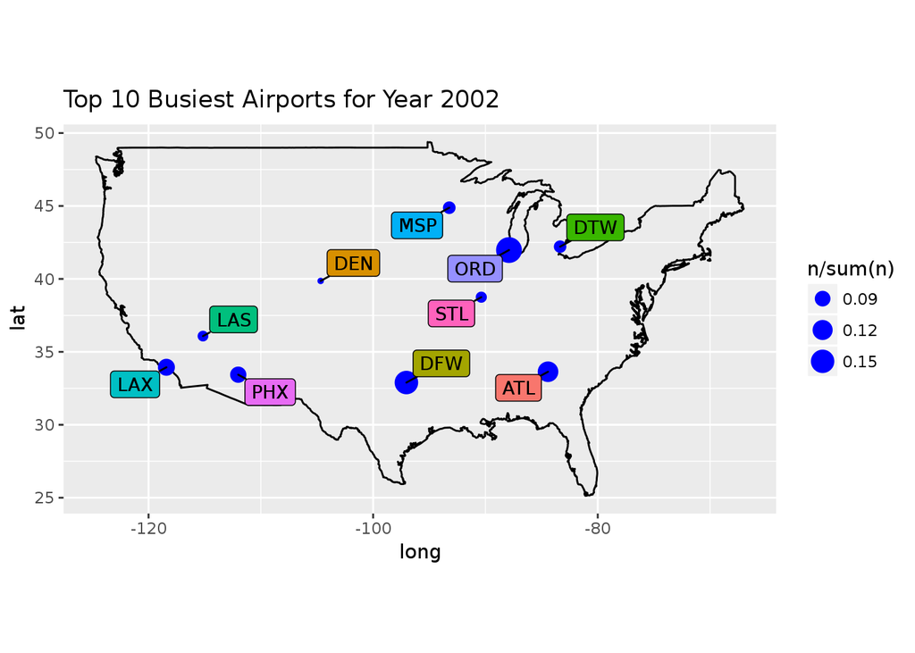

```r
#plot the 10 busiest airports on map

usa <- map_data("usa")



us_map <- ggplot() +
  geom_polygon(data = usa, aes(x = long, y = lat, group = group), fill = NA, color = "black") +
  coord_fixed(1.3) +
  guides(fill=FALSE)

map1 <- us_map +
  geom_point(data = location,
             aes(x = lon, y = lat, size = n/sum(n)),
             color = "blue")

map1 <- map1 +
  geom_label_repel(data = location,
                   aes(x = lon, y = lat, label = airport, size = n/sum(n),
                       fill = factor(airport)), min.segment.length = 0,
                   size = 3.5) +
  ggtitle("Top 10 Busiest Airports for Year 2002")
map1
```

This map represents the top 10 busiest airports for the year 2002 plotted on the U.S. map (size of dot is proportional/scaled to how many flights this airport receives).

**2. Map the top 10 busiest direct routes. Size of lines should reflect the number of flights through that route.**

```r
#Find top routes
  top_routes <- flights_tbl %>%
    filter(year == 2002) %>%
    group_by(origin, dest) %>%
    count() %>%
    arrange(desc(n)) %>%
    ungroup() %>%
    collect() %>%
    head(10)

#Consolidate top 10 routes into a table. Get longitude and latitude for each route.
  route_location <- top_routes %>%

    left_join(airports_tbl, by = c("origin" = "faa"), copy = TRUE) %>%
    mutate(origin_longitude = lon, origin_latitude = lat) %>%

    select(origin, dest, origin_longitude, origin_latitude, n) %>%
    left_join(airports_tbl, by = c("dest" = "faa"), copy = TRUE) %>%

    mutate(lon_dest = lon, lat_dest = lat) %>%
    select(origin, dest, origin_longitude, origin_latitude,
           lon_dest, lat_dest, n) %>%
    mutate(origin_longitude = as.double(origin_longitude),
           origin_latitude = as.double(origin_latitude),
           lon_dest = as.double(lon_dest),
           lat_dest = as.double(lat_dest)) %>%
    collect()

  route_location
```

```
## # A tibble: 10 x 7
##    origin dest  origin_longitude origin_latitude lon_dest lat_dest      n
##    <chr>  <chr>            <dbl>           <dbl>    <dbl>    <dbl>  <dbl>
##  1 LAX    LAS             -118.             33.9   -115.      36.1 12733.
##  2 LAS    LAX             -115.             36.1   -118.      33.9 12526.
##  3 MSP    ORD              -93.2            44.9    -87.9     42.0 12007.
##  4 ORD    MSP              -87.9            42.0    -93.2     44.9 11907.
##  5 BOS    LGA              -71.0            42.4    -73.9     40.8 11539.
##  6 LGA    BOS              -73.9            40.8    -71.0     42.4 11537.
##  7 LAS    PHX             -115.             36.1   -112.      33.4 11143.
##  8 PHX    LAS             -112.             33.4   -115.      36.1 11091.
##  9 PHX    LAX             -112.             33.4   -118.      33.9 11066.
## 10 LAX    PHX             -118.             33.9   -112.      33.4 11027.
```

From this table, the top 10 busiest routes for the year 2002 are:

- LAX to LAS
- LAS to LAX
- MSP to ORD
- ORD to MSP
- BOS to LGA
- LGA to BOS
- LAS to PHX
- PHX to LAS
- LAX to PHX
- PHX to LAX

in descending order. Each row in this table represents total number of flights of one specific route (i.e. one specific origin airport to destination airport). Table is arranged in descending order. A route is defined as having one specific airport as the origin and another airport as the destination. Each route is treated separately i.e. route from LAX to LAS is one route, and route from LAS to LAX is one different route.

```r
#Make proportional line sizes
route_location <- route_location %>%
  mutate(size_prop = ((n / sum(n)) * 3)) %>%
  collect()


#Get the airport origin that had top origin and destination
airport_origin <- top_routes$origin
airport_destination <- top_routes$dest

#Make a table of the top routes
airport_routes <- as_tibble(unique(c(airport_origin, airport_destination)))
colnames(airport_routes) <- c("airport")




#Make table of top routes and include longitude and latitude for plotting on US map
airport_routes <- airport_routes %>%
  left_join(airports_tbl, by = c("airport" = "faa"), copy = TRUE) %>%
  mutate(lon = as.double(lon), lat = as.double(lat)) %>%
  select(airport, lon, lat)

airport_routes
```

```
## # A tibble: 7 x 3
##   airport    lon   lat
##   <chr>    <dbl> <dbl>
## 1 LAX     -118.   33.9
## 2 LAS     -115.   36.1
## 3 MSP      -93.2  44.9
## 4 ORD      -87.9  42.0
## 5 BOS      -71.0  42.4
## 6 LGA      -73.9  40.8
## 7 PHX     -112.   33.4
```

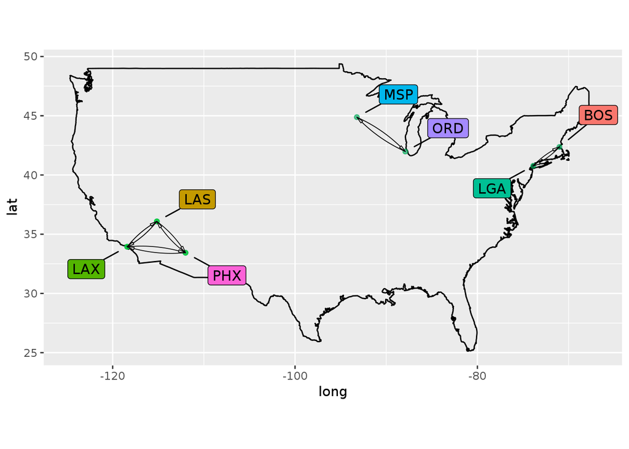

```r
#Plot top 10 routes on U.S. map
usa <- map_data("usa")

us_airport_routes <- ggplot() +

  geom_polygon(data = usa, aes(x = long, y = lat, group = group),
               fill = NA, color = "black") +
  coord_fixed(1.3) + guides(fill=FALSE)

#Draw points for the airport origin and destinations. Draw curve for routes
us_airport_routes +

  geom_point(data = route_location,
             aes(x = origin_longitude, y = origin_latitude),
             colour = "blue", alpha = 0.4) +

  geom_point(data = route_location,
             aes(x = lon_dest, y = lat_dest),
             colour = "green", alpha = 0.4) +

  geom_curve(data = route_location,
             aes(x = origin_longitude, y = origin_latitude, xend = lon_dest,
                 yend = lat_dest), arrow = arrow(angle = 10, ends = "first",
                 length = unit(0.2, "cm"), type = "closed"),
                 size = route_location$size_prop, curvature = 0.1,
                 inherit.aes = TRUE) +

  geom_label_repel(data = airport_routes,
                   aes(x = lon, y = lat, label = airport,
                       fill = factor(airport)),
                       point.padding = 1, min.segment.length = 0, size = 4)
```

It is difficult to distinguish the different sizes of the lines because the total number of flights in each route are close in number (range from about 11,000 to about 13,00) out of a total of about 116,000 flights. So, the proportion of the top 10 busiest routes range from 9% to 11%, which would be difficult to distinguish.